# Mozilla Data Science Project - 2019

Mariana de Oliveira Santos Silva

Last Updated: janeiro 09, 2020

# Introduction

In this second report, we will demonstrate how to get started with matching methods using R and the [MatchIt](https://cran.r-project.org/web/packages/MatchIt/MatchIt.pdf) package.

> *“Matching is a nonparametric method of preprocessing data to control for some or all of the potentially confounding influence of pretreatment control variables by reducing imbalance between the treated and control groups. After preprocessing in this way, any method of analysis that would have been used without matching can be applied to estimate causal effects.”* **- [Gary King](http://gking.harvard.edu/cem)**

# Loading the data

To begin we need to load some data. We will use as example a data set previously analyzed extensively by [Lalonde (1986)](http://business.baylor.edu/scott_cunningham/teaching/lalonde-1986.pdf) and [Dehejia and Wahba (1999)](https://www.ics.uci.edu/~sternh/courses/265/dehejiawahba_jasa1999.pdf). In this data set, there is a subsample of the data from the treated group in the National Supported Work Demonstration (NSW) and the comparison sample from the Current Population Survey (CPS).

```r
## Loading data: a subset of the LaLonde data is loaded with the MatchIt library

data(lalonde)
```

# Data Inspection

| rows | columns | discrete_columns | continuous_columns | all_missing_columns | total_missing_values | complete_rows | total_observations | memory_usage |
| --- | --- | --- | --- | --- | --- | --- | --- | --- |
| 614 | 10 | 0 | 10 | 0 | 0 | 614 | 6140 | 34896 |

To perform matching methods, we will need a data set that consists of cases in rows and variables in columns. We will need a **dependent variable** and one or more matching variables. The dependent variable is the variable that specifies which group a case belongs to (e.g., treatment or control). In this example, our dependent variable is `treat`, where $1$ means treatment and $0$, control.

```r
## View LaLonde dataframe

kable(head(lalonde, 10)) %>%
kable_styling(bootstrap_options = c("striped", "hover", "condensed"), full_width = F) %>%
scroll_box(width = "100%")
```

|  | treat | age | educ | black | hispan | married | nodegree | re74 | re75 | re78 |
| --- | --- | --- | --- | --- | --- | --- | --- | --- | --- | --- |
| NSW1 | 1 | 37 | 11 | 1 | 0 | 1 | 1 | 0 | 0 | 9930.0460 |
| NSW2 | 1 | 22 | 9 | 0 | 1 | 0 | 1 | 0 | 0 | 3595.8940 |
| NSW3 | 1 | 30 | 12 | 1 | 0 | 0 | 0 | 0 | 0 | 24909.4500 |
| NSW4 | 1 | 27 | 11 | 1 | 0 | 0 | 1 | 0 | 0 | 7506.1460 |
| NSW5 | 1 | 33 | 8 | 1 | 0 | 0 | 1 | 0 | 0 | 289.7899 |
| NSW6 | 1 | 22 | 9 | 1 | 0 | 0 | 1 | 0 | 0 | 4056.4940 |
| NSW7 | 1 | 23 | 12 | 1 | 0 | 0 | 0 | 0 | 0 | 0.0000 |
| NSW8 | 1 | 32 | 11 | 1 | 0 | 0 | 1 | 0 | 0 | 8472.1580 |
| NSW9 | 1 | 22 | 16 | 1 | 0 | 0 | 0 | 0 | 0 | 2164.0220 |
| NSW10 | 1 | 33 | 12 | 0 | 0 | 1 | 0 | 0 | 0 | 12418.0700 |

## Observations

- 614 observations: 185 treated, 429 control
- 10 variables measured for each individual:
- Outcome (`re78`) = income in 1978, in U.S.
- Treatment (`treat`) = participation in job training (1 = treated, 0 = control)
- Training Covariants:
  - `age` is age in years
  - `educ` is education in number of years of schooling
  - `black` is an indicator for African-American (1 = African-American, 0 = not)
  - `hispan` is an indicator for being of Hispanic origin (1 = Hispanic, 0 = not)
  - `married` is an indicator for married (1 = married, 0 = not married)
  - `nodegree` is an indicator for whether the individual has a high school degree (1 = no degree, 0 = degree)
  - `re74` is income in 1974, in U.S. dollars
  - `re75` is income in 1975, in U.S. dollars

# Data Structure

```r
glimpse(lalonde)
```

```
## Observations: 614
## Variables: 10
## $ treat    <int> 1, 1, 1, 1, 1, 1, 1, 1, 1, 1, 1, 1, 1, 1, 1, 1, 1, 1,...
## $ age      <int> 37, 22, 30, 27, 33, 22, 23, 32, 22, 33, 19, 21, 18, 2...
## $ educ     <int> 11, 9, 12, 11, 8, 9, 12, 11, 16, 12, 9, 13, 8, 10, 7,...
## $ black    <int> 1, 0, 1, 1, 1, 1, 1, 1, 1, 0, 1, 1, 1, 1, 1, 1, 1, 1,...
## $ hispan   <int> 0, 1, 0, 0, 0, 0, 0, 0, 0, 0, 0, 0, 0, 0, 0, 0, 0, 0,...
## $ married  <int> 1, 0, 0, 0, 0, 0, 0, 0, 0, 1, 0, 0, 0, 1, 0, 0, 0, 0,...
## $ nodegree <int> 1, 1, 0, 1, 1, 1, 0, 1, 0, 0, 1, 0, 1, 1, 1, 1, 0, 1,...
## $ re74     <dbl> 0, 0, 0, 0, 0, 0, 0, 0, 0, 0, 0, 0, 0, 0, 0, 0, 0, 0,...
## $ re75     <dbl> 0, 0, 0, 0, 0, 0, 0, 0, 0, 0, 0, 0, 0, 0, 0, 0, 0, 0,...
## $ re78     <dbl> 9930.0460, 3595.8940, 24909.4500, 7506.1460, 289.7899...
```

```r
kable(df_status(lalonde, FALSE)) %>%
kable_styling(bootstrap_options = c("striped", "hover", "condensed"), full_width = F) %>%
scroll_box(width = "100%")
```

| variable | q_zeros | p_zeros | q_na | p_na | q_inf | p_inf | type | unique |
| --- | --- | --- | --- | --- | --- | --- | --- | --- |
| treat | 429 | 69.87 | 0 | 0 | 0 | 0 | integer | 2 |
| age | 0 | 0.00 | 0 | 0 | 0 | 0 | integer | 40 |
| educ | 3 | 0.49 | 0 | 0 | 0 | 0 | integer | 19 |
| black | 371 | 60.42 | 0 | 0 | 0 | 0 | integer | 2 |
| hispan | 542 | 88.27 | 0 | 0 | 0 | 0 | integer | 2 |
| married | 359 | 58.47 | 0 | 0 | 0 | 0 | integer | 2 |
| nodegree | 227 | 36.97 | 0 | 0 | 0 | 0 | integer | 2 |
| re74 | 243 | 39.58 | 0 | 0 | 0 | 0 | numeric | 358 |
| re75 | 245 | 39.90 | 0 | 0 | 0 | 0 | numeric | 356 |
| re78 | 143 | 23.29 | 0 | 0 | 0 | 0 | numeric | 457 |

- Composition:

```r
f <- freq(lalonde$treat)
```

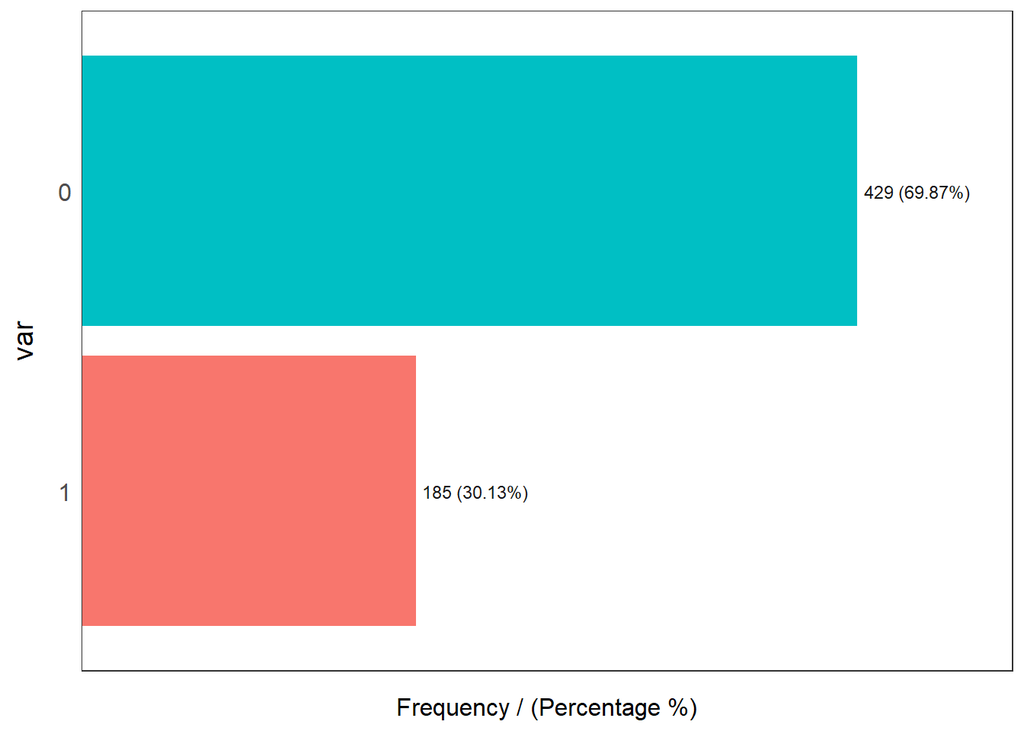

# Propensity Score Matching

In this tutorial we’ll analyze the effect of participating in job training, as opposed to not participate, on income in 1978 dollars. We will use propensity score matching to get more credible causal estimates of job training.

To examine the effect of participating in job training (“Treated”) versus non-participation (“Control”) on income using matching we will go through the following steps:

1. Preliminary analysis
2. Estimation of Propensity scores (the probability of being Treated given a set of pre-treatment covariates)
3. Propensity Score matching. We’ll use the following matching methods:
1. Coarsened Exact Matching (CEM)
2. Nearest neighbor matching
3. Nearest neighbor matching, with Mahalanobis distance measure
4. Outcome analysis
5. Sensitivity analysis

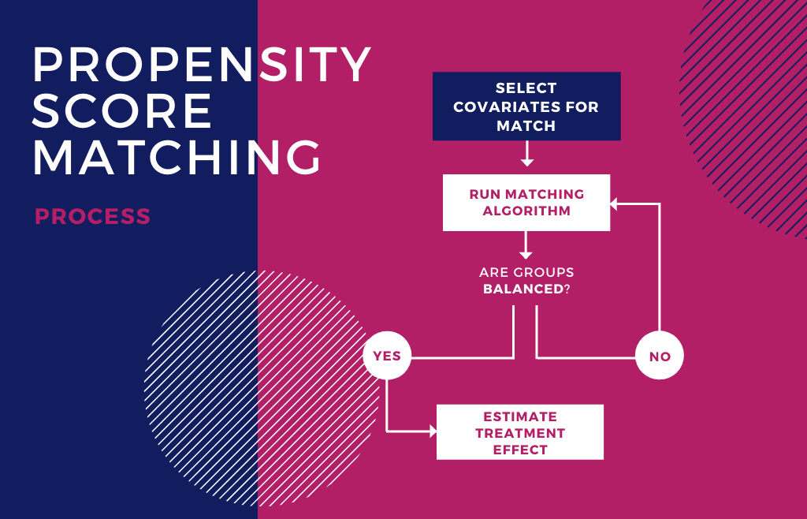

## Preliminary Analysis (using unmatched data)

Before propensity scores are calculated, it is a good practice to determine if the two groups are balanced. The best practice to determine the covariates that influence group assignment is based on theoretical evidence. In addition, statistical tests can also be used to determine if the covariates are imbalanced across groups. The package [RItools](https://cran.r-project.org/web/packages/RItools/index.html) includes the routine `XBalance` that estimates a chi-square test to which checks if there is at least one variable in the selection model for which the two groups are different.

### Computing indices of covariate imbalance before matching

#### 1. Standardized difference

```r
treated <- (lalonde$treat==1)
cov <- lalonde[,2:9]
std.diff <- apply(cov,2,function(x) 100*(mean(x[treated])- mean(x[!treated]))/(sqrt(0.5*(var(x[treated]) + var(x[!treated])))))
sort(abs(std.diff))
```

```
##       educ   nodegree        age     hispan       re75       re74
##   4.475509  23.504820  24.190362  27.693960  28.700211  59.575159
##    married      black
##  71.949196 166.771881
```

For the standardized difference, absolute scores higher than $25%$ are considered suspect, and may indicate an imbalance for that specific variable [(Stuart & Rubin, 2008)](http://citeseerx.ist.psu.edu/viewdoc/download;jsessionid=F52F07E838B6B1B9DB8B05FB10AAE7CB?doi=10.1.1.584.1057&rep=rep1&type=pdf). That is, `hispan`, `re75`, `re74`, `married` and `black`.

#### 2. Check initial balance

- *How similar are treatment/control groups on X?*

```r
xBalance(treat ~ . - (re78 + treat), data=lalonde, report=c("all"))
```

```
##          strata   unstrat
##          stat     treat=0   treat=1  adj.diff adj.diff.null.sd  std.diff      z
## vars
## age             2.80e+01  2.58e+01  -2.21e+00        8.69e-01  -2.25e-01 -2.55e+00 *
## educ            1.02e+01  1.03e+01  1.11e-01         2.31e-01  4.20e-02  4.78e-01
## black           2.03e-01  8.43e-01  6.40e-01         4.30e-02  1.64e+00  1.49e+01  ***
## hispan          1.42e-01  5.95e-02  -8.27e-02        2.83e-02  -2.59e-01 -2.92e+00 **
## married         5.13e-01  1.89e-01  -3.24e-01        4.34e-02  -6.88e-01 -7.46e+00 ***
## nodegree        5.97e-01  7.08e-01  1.11e-01         4.25e-02  2.32e-01  2.62e+00  **
## re74            5.62e+03  2.10e+03  -3.52e+03        5.70e+02  -5.61e-01 -6.18e+00 ***
## re75            2.47e+03  1.53e+03  -9.34e+02        2.90e+02  -2.86e-01 -3.22e+00 **
## ---Overall Test---
##         chisquare df  p.value
## unstrat       238  8 6.17e-47
## ---
## Signif. codes:  0 '***' 0.001 '** ' 0.01 '*  ' 0.05 '.  ' 0.1 '   ' 1
```

A statistically significant chi-square will indicate that at least one of the variables included in the model is creating an imbalance between the two groups. Variables that create imbalance should be included in the selection model. Also as part of the preliminary analysis it is a good practice to assess the effects of the treatment on the outcome variable by running the outcome model. This assessment can be based on the treatment variable only (using a t-test), or include covariates (using a regression model).

### Treatment effect without matching: difference of means

```r
unmatched <- lm(re78 ~ treat, data=lalonde)
summary(unmatched)
```

```
##
## Call:
## lm(formula = re78 ~ treat, data = lalonde)
##
## Residuals:
##    Min     1Q Median     3Q    Max
##  -6984  -6349  -2048   4100  53959
##
## Coefficients:
##             Estimate Std. Error t value Pr(>|t|)
## (Intercept)   6984.2      360.7  19.362   <2e-16 ***
## treat         -635.0      657.1  -0.966    0.334
## ---
## Signif. codes:  0 '***' 0.001 '**' 0.01 '*' 0.05 '.' 0.1 ' ' 1
##
## Residual standard error: 7471 on 612 degrees of freedom
## Multiple R-squared:  0.001524,   Adjusted R-squared:  -0.0001079
## F-statistic: 0.9338 on 1 and 612 DF,  p-value: 0.3342
```

```r
effect <- unmatched$coeff[2]
effect
```

```
##     treat
## -635.0262
```

### Treatment effect without matching: regression

```r
unmatched <- lm(re78 ~ treat + age + educ + nodegree + re74 + re75 + married + black + hispan, data = lalonde)
summary(unmatched)
```

```
##
## Call:
## lm(formula = re78 ~ treat + age + educ + nodegree + re74 + re75 +
##     married + black + hispan, data = lalonde)
##
## Residuals:
##    Min     1Q Median     3Q    Max
## -13595  -4894  -1662   3929  54570
##
## Coefficients:
##               Estimate Std. Error t value Pr(>|t|)
## (Intercept)  6.651e+01  2.437e+03   0.027   0.9782
## treat        1.548e+03  7.813e+02   1.982   0.0480 *
## age          1.298e+01  3.249e+01   0.399   0.6897
## educ         4.039e+02  1.589e+02   2.542   0.0113 *
## nodegree     2.598e+02  8.474e+02   0.307   0.7593
## re74         2.964e-01  5.827e-02   5.086 4.89e-07 ***
## re75         2.315e-01  1.046e-01   2.213   0.0273 *
## married      4.066e+02  6.955e+02   0.585   0.5590
## black       -1.241e+03  7.688e+02  -1.614   0.1071
## hispan       4.989e+02  9.419e+02   0.530   0.5966
## ---
## Signif. codes:  0 '***' 0.001 '**' 0.01 '*' 0.05 '.' 0.1 ' ' 1
##
## Residual standard error: 6948 on 604 degrees of freedom
## Multiple R-squared:  0.1478, Adjusted R-squared:  0.1351
## F-statistic: 11.64 on 9 and 604 DF,  p-value: < 2.2e-16
```

## Propensity Score Estimation

Packages such as MatchIt estimates propensity scores using logistic regression as the default option. However, when estimating propensity scores using the default option, the fit of the model cannot be assessed. Therefore, it is recommended that a logistic regression is run to determine the model fit.

### Calculates the propensity score

```r
ps <- glm(treat ~ age + educ + nodegree + re74 + re75, data=lalonde, family=binomial())
summary(ps)
```

```
##
## Call:
## glm(formula = treat ~ age + educ + nodegree + re74 + re75, family = binomial(),
##     data = lalonde)
##
## Deviance Residuals:
##     Min       1Q   Median       3Q      Max
## -1.2559  -0.9053  -0.6053   1.2060   2.9809
##
## Coefficients:
##               Estimate Std. Error z value Pr(>|z|)
## (Intercept) -2.694e+00  7.989e-01  -3.372 0.000746 ***
## age          2.464e-03  1.025e-02   0.240 0.810019
## educ         1.569e-01  5.299e-02   2.962 0.003059 **
## nodegree     8.502e-01  2.813e-01   3.023 0.002503 **
## re74        -1.225e-04  2.576e-05  -4.756 1.98e-06 ***
## re75         2.574e-05  3.955e-05   0.651 0.515252
## ---
## Signif. codes:  0 '***' 0.001 '**' 0.01 '*' 0.05 '.' 0.1 ' ' 1
##
## (Dispersion parameter for binomial family taken to be 1)
##
##     Null deviance: 751.49  on 613  degrees of freedom
## Residual deviance: 692.88  on 608  degrees of freedom
## AIC: 704.88
##
## Number of Fisher Scoring iterations: 5
```

Statistically significant estimates are identified by low (i.e., $< 0.05$) p-values. There are no clear suggestions as to whether to include in the final model all the variables (even non-significant). Some authors suggest that the final model should include not only statistically significant variables, but also variables known to be associated with selection.

Once the propensity scores have been calculated, a graphical approach can be used to assess the distributional similarity between score distributions. This graphical approach uses back to back histograms such as those created through the package Hmisc. Back to back histograms cannot be used with Mahalanobis distance, because it is a multidimensional technique.

- Attach the predicted propensity score to the datafile

```r
lalonde$psvalue <- predict(ps, type="response")
```

### Back to back histogram

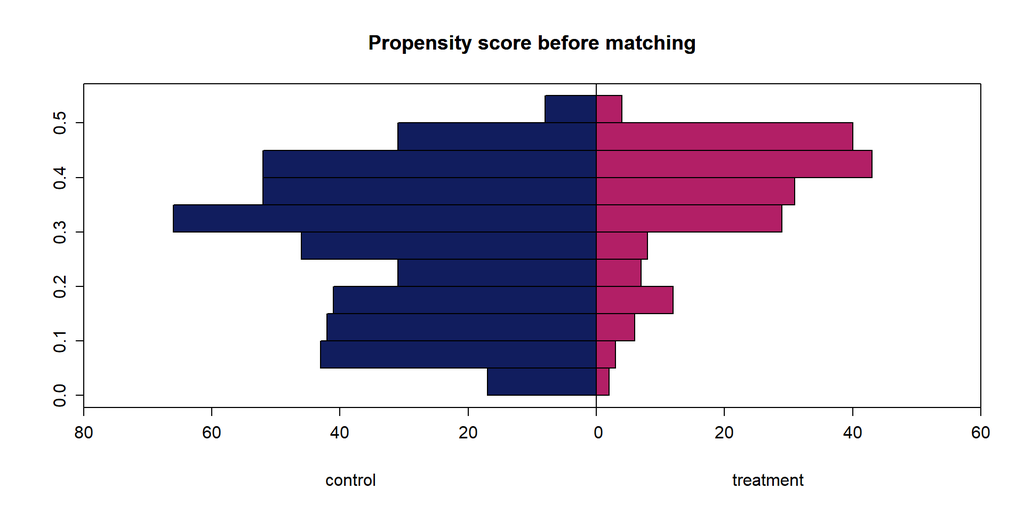

```r
out <- histbackback(split(lalonde$psvalue, lalonde$treat), main="Propensity score before matching", xlab=c("control", "treatment"))
#! just adding color
barplot(-out$left, col="#111d5e" , horiz=TRUE, space=0, add=TRUE, axes=FALSE)
barplot(out$right, col="#b21f66", horiz=TRUE, space=0, add=TRUE, axes=FALSE)
```

Important parameters to determine the fit are not only the shape, but also degree of overlap between the two distributions (known as the common support region). Matching is best when there is a common support region.

## Propensity Score Matching

Packages such as MatchIt provide summary tables that include means and standard deviations for the two groups both before and after the matching was completed. It also includes percent improvement, and finally, it provides a summary of the number of individuals included in the final sample, and cases that were not matched. The number of matched and unmatched cases is usually dependent on the match ratio imposed by the user, and the number of cases in the treatment group.

### Match using Coarsened Exact Matching (CEM)

Coarsened Exact Matching (CEM) is a Monotonic Imbalance Bounding (MIB) matching method - which means that the balance between the treated and control groups is chosen by the user ex-ante rather than discovered through the usual laborious process of checking after the fact and repeatedly reestimating, and so that adjusting the imbalance on one variable has no effect on the maximum imbalance of any other. CEM also strictly bounds through ex-ante user choice both the degree of model dependence and the average treatment effect estimation error, eliminates the need for a separate procedure to restrict data to common empirical support, meets the congruence principle, is robust to measurement error, works well with multiple imputation methods for missing data, and is extremely fast computationally even with very large data sets. CEM also works well for multicategory treatments, determining blocks in experimental designs, and evaluating extreme counterfactuals.

```r
m.cem <- matchit(treat ~ age + educ + nodegree + re74 + re75, data=lalonde, method="cem")
```

```
##
## Using 'treat'='1' as baseline group
```

```r
summary(m.cem)
```

```
##
## Call:
## matchit(formula = treat ~ age + educ + nodegree + re74 + re75,
##     data = lalonde, method = "cem")
##
## Summary of balance for all data:
##          Means Treated Means Control SD Control  Mean Diff   eQQ Med
## distance        0.3650        0.2738     0.1337     0.0912    0.0893
## age            25.8162       28.0303    10.7867    -2.2141    1.0000
## educ           10.3459       10.2354     2.8552     0.1105    1.0000
## nodegree        0.7081        0.5967     0.4911     0.1114    0.0000
## re74         2095.5737     5619.2365  6788.7508 -3523.6628 2425.5720
## re75         1532.0553     2466.4844  3291.9962  -934.4291  981.0968
##           eQQ Mean   eQQ Max
## distance    0.0920    0.1734
## age         3.2649   10.0000
## educ        0.7027    4.0000
## nodegree    0.1135    1.0000
## re74     3620.9240 9216.5000
## re75     1060.6582 6795.0100
##
##
## Summary of balance for matched data:
##          Means Treated Means Control SD Control Mean Diff  eQQ Med
## distance        0.3740        0.3613     0.0873    0.0126   0.0124
## age            24.2623       23.9431     6.6611    0.3192   3.0000
## educ           10.2377       10.2395     2.0012   -0.0018   0.0000
## nodegree        0.6885        0.6885     0.4643    0.0000   0.0000
## re74          933.4265     1414.8553  2313.3087 -481.4288 120.4949
## re75          538.5095      721.6906  1402.6244 -183.1811  24.0590
##          eQQ Mean   eQQ Max
## distance   0.0129    0.0359
## age        2.7623    5.0000
## educ       0.2049    1.0000
## nodegree   0.0082    1.0000
## re74     448.3898 1933.7960
## re75     211.6560 1701.2500
##
## Percent Balance Improvement:
##          Mean Diff.   eQQ Med eQQ Mean eQQ Max
## distance    86.1618   86.0957  85.9518 79.3174
## age         85.5835 -200.0000  15.3933 50.0000
## educ        98.3537  100.0000  70.8386 75.0000
## nodegree   100.0000    0.0000  92.7791  0.0000
## re74        86.3373   95.0323  87.6167 79.0181
## re75        80.3965   97.5477  80.0448 74.9632
##
## Sample sizes:
##           Control Treated
## All           429     185
## Matched       190     122
## Unmatched     239      63
## Discarded       0       0
```

```r
match.data.1 = match.data(m.cem)
```

### Match using Nearest neighbor matching

Nearest neighbor matching selects the $r$ (default=1) best control matches for each individual in the treatment group (excluding those discarded using the `discard` option). Matching is done using a distance measure specified by the `distance` option (default=logit). Matches are chosen for each treated unit one at a time, with the order specified by the `m.order` command (default=largest to smallest). At each matching step, we choose the control unit that is not yet matched but is closest to the treated unit on the distance measure.

```r
m.nn <- matchit(treat ~ age + educ + nodegree + re74 + re75, data=lalonde, method="nearest", ratio = 1)
summary(m.nn)
```

```
##
## Call:
## matchit(formula = treat ~ age + educ + nodegree + re74 + re75,
##     data = lalonde, method = "nearest", ratio = 1)
##
## Summary of balance for all data:
##          Means Treated Means Control SD Control  Mean Diff   eQQ Med
## distance        0.3650        0.2738     0.1337     0.0912    0.0893
## age            25.8162       28.0303    10.7867    -2.2141    1.0000
## educ           10.3459       10.2354     2.8552     0.1105    1.0000
## nodegree        0.7081        0.5967     0.4911     0.1114    0.0000
## re74         2095.5737     5619.2365  6788.7508 -3523.6628 2425.5720
## re75         1532.0553     2466.4844  3291.9962  -934.4291  981.0968
##           eQQ Mean   eQQ Max
## distance    0.0920    0.1734
## age         3.2649   10.0000
## educ        0.7027    4.0000
## nodegree    0.1135    1.0000
## re74     3620.9240 9216.5000
## re75     1060.6582 6795.0100
##
##
## Summary of balance for matched data:
##          Means Treated Means Control SD Control Mean Diff  eQQ Med
## distance        0.3650        0.3603     0.1092    0.0047   0.0016
## age            25.8162       24.7838     9.6480    1.0324   3.0000
## educ           10.3459       10.1676     2.6166    0.1784   0.0000
## nodegree        0.7081        0.7459     0.4365   -0.0378   0.0000
## re74         2095.5737     2218.4725  4371.6213 -122.8988 104.5930
## re75         1532.0553     1428.9774  2297.0371  103.0779 172.5310
##          eQQ Mean    eQQ Max
## distance   0.0052     0.0303
## age        2.9568     8.0000
## educ       0.5351     4.0000
## nodegree   0.0378     1.0000
## re74     445.2718  9177.7500
## re75     409.0697 13737.8900
##
## Percent Balance Improvement:
##          Mean Diff.   eQQ Med eQQ Mean   eQQ Max
## distance    94.8731   98.2359  94.3852   82.4986
## age         53.3698 -200.0000   9.4371   20.0000
## educ       -61.4069  100.0000  23.8462    0.0000
## nodegree    66.0256    0.0000  66.6667    0.0000
## re74        96.5122   95.6879  87.7028    0.4204
## re75        88.9689   82.4145  61.4325 -102.1762
##
## Sample sizes:
##           Control Treated
## All           429     185
## Matched       185     185
## Unmatched     244       0
## Discarded       0       0
```

```r
match.data.2 = match.data(m.nn)
```

### Match using Nearest neighbor matching, with Mahalanobis distance measure

```r
m.nnm <- matchit(treat ~ age + educ + nodegree + re74 + re75, data=lalonde, method="nearest", ratio=1, distance="mahalanobis")
summary(m.nnm)
```

```
##
## Call:
## matchit(formula = treat ~ age + educ + nodegree + re74 + re75,
##     data = lalonde, method = "nearest", distance = "mahalanobis",
##     ratio = 1)
##
## Summary of balance for all data:
##          Means Treated Means Control SD Control  Mean Diff   eQQ Med
## age            25.8162       28.0303    10.7867    -2.2141    1.0000
## educ           10.3459       10.2354     2.8552     0.1105    1.0000
## nodegree        0.7081        0.5967     0.4911     0.1114    0.0000
## re74         2095.5737     5619.2365  6788.7508 -3523.6628 2425.5720
## re75         1532.0553     2466.4844  3291.9962  -934.4291  981.0968
##           eQQ Mean eQQ Max
## age         3.2649   10.00
## educ        0.7027    4.00
## nodegree    0.1135    1.00
## re74     3620.9240 9216.50
## re75     1060.6582 6795.01
##
##
## Summary of balance for matched data:
##          Means Treated Means Control SD Control Mean Diff  eQQ Med
## age            25.8162       25.0324     8.4074    0.7838   2.0000
## educ           10.3459       10.3027     2.0917    0.0432   0.0000
## nodegree        0.7081        0.7027     0.4583    0.0054   0.0000
## re74         2095.5737     2488.5229  4338.3333 -392.9492 295.8493
## re75         1532.0553     1589.8355  2734.7001  -57.7801 131.8490
##          eQQ Mean eQQ Max
## age        1.7243    4.00
## educ       0.1297    1.00
## nodegree   0.0054    1.00
## re74     688.8471 9504.95
## re75     288.3768 6795.01
##
## Percent Balance Improvement:
##          Mean Diff.   eQQ Med eQQ Mean eQQ Max
## age         64.6001 -100.0000  47.1854 60.0000
## educ        60.8711  100.0000  81.5385 75.0000
## nodegree    95.1465    0.0000  95.2381  0.0000
## re74        88.8483   87.8029  80.9759 -3.1297
## re75        93.8165   86.5611  72.8115  0.0000
##
## Sample sizes:
##           Control Treated
## All           429     185
## Matched       185     185
## Unmatched     244       0
## Discarded       0       0
```

```r
match.data.3 = match.data(m.nnm)
```

Graphical approaches (such as the jitter type in the package MatchIt), will help the user get some idea of whether the individuals not matched are in some specific part of the propensity-score continuum. The jitter plot shows the overall distribution of propensity scores in the treated and control groups.

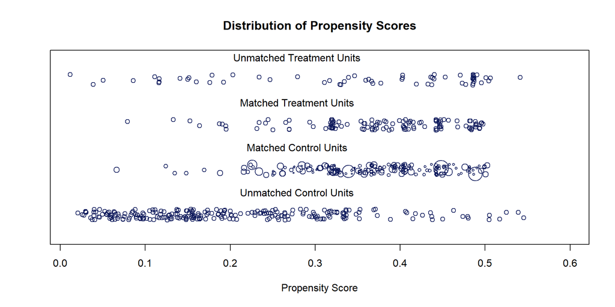

```
## [1] "To identify the units, use first mouse button; to stop, use second."
```

```
## integer(0)
```

```r
plot(m.cem, type = "jitter", col = "#111d5e")
```

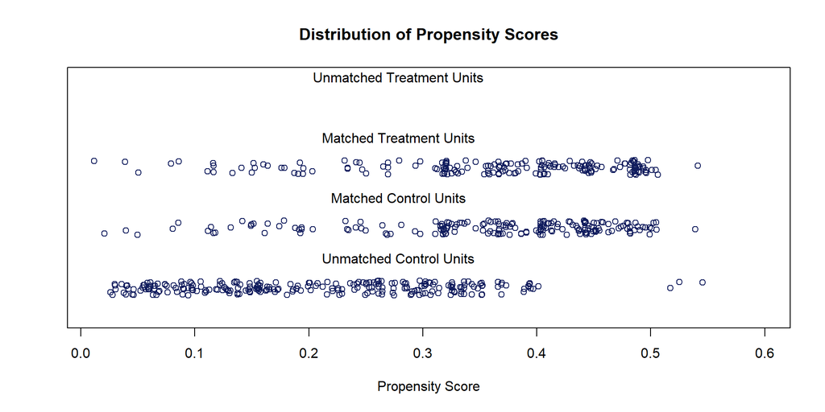

```
## [1] "To identify the units, use first mouse button; to stop, use second."
```

```
## integer(0)
```

```r
plot(m.nn, type = "jitter", col = "#111d5e")
```

```r
#plot(m.nnm, type = "jitter", col = "#111d5e") ## Not appropriate for pure Mahalanobis matching. No plots generated.
```

As can be observed in this figure, the section labeled “Unmatched control Units” shows that most of the non-matched individuals were in the lower (0.0 to 0.4) part of the propensity scores. However, there were a few cases in a higher range (0.5-0.6).

It is important to determine that the groups are balanced, thus eliminating (or substantially reducing) the initial selection bias. In step 1 in this section (preliminary analysis) it was mentioned that there are both statistical as well as graphical approaches that can be used to determine the degree of imbalance. After the match has been conducted, both techniques are used again to determine that all the critical variables have been balanced.

### Computing indices of covariate imbalance after matching

```r
### 1. Standardized difference
treated1 <- (match.data.2$treat==1)
cov1 <- match.data.2[,2:9]
std.diff1 <- apply(cov1,2,function(x) 100*(mean(x[treated1])- mean(x[!treated1]))/(sqrt(0.5*(var(x[treated1]) + var(x[!treated1])))))
abs(std.diff1)
```

```
##        age       educ      black     hispan    married   nodegree
##  12.155616   7.644579 154.578773  34.492122  38.194233   8.478250
##       re74       re75
##   2.650808   3.686064
```

```r
### 2. chi-square test
xBalance(treat ~ age + educ + nodegree + re74 + re75, data = match.data.2, report = c("chisquare.test"))
```

```
## ---Overall Test---
##         chisquare df p.value
## unstrat      2.64  5   0.755
## ---
## Signif. codes:  0 '***' 0.001 '** ' 0.01 '*  ' 0.05 '.  ' 0.1 '   ' 1
```

Although the chi-square test indicates no significance, thus suggesting equivalence between the groups, the standardized difference test shows that there are some variables with a large difference (i.e., black, hispan, married) that can still be improved. Potential suggestions might include the use of interactions terms, or polynomial terms to try to reduce their imbalance. A graphical approach that can be used to determine the match between groups is the back to back histograms.

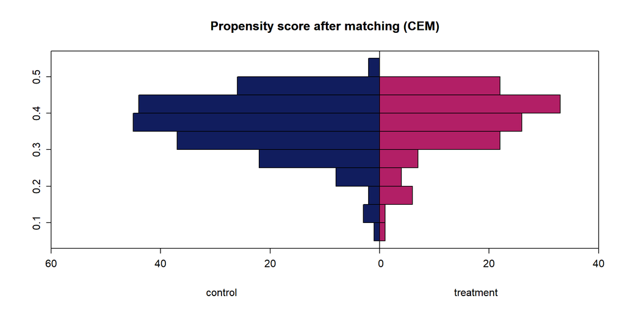

```r
out <- histbackback(split(match.data.1$psvalue, match.data.1$treat), main= "Propensity score after matching (CEM)", xlab=c("control", "treatment"))
barplot(-out$left, col="#111d5e" , horiz=TRUE, space=0, add=TRUE, axes=FALSE)
barplot(out$right, col="#b21f66", horiz=TRUE, space=0, add=TRUE, axes=FALSE)
```

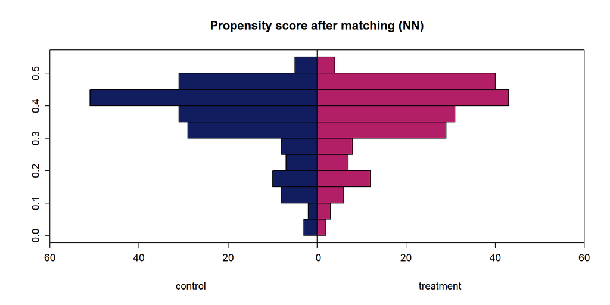

```r
out <- histbackback(split(match.data.2$psvalue, match.data.2$treat), main= "Propensity score after matching (NN)", xlab=c("control", "treatment"))
barplot(-out$left, col="#111d5e" , horiz=TRUE, space=0, add=TRUE, axes=FALSE)
barplot(out$right, col="#b21f66", horiz=TRUE, space=0, add=TRUE, axes=FALSE)
```

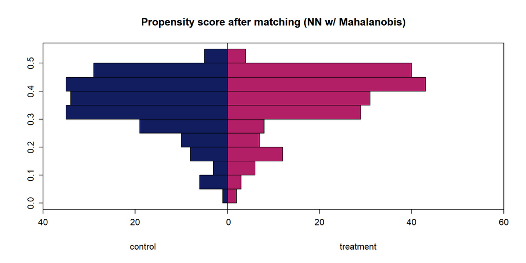

```r
out <- histbackback(split(match.data.3$psvalue, match.data.3$treat), main= "Propensity score after matching (NN w/ Mahalanobis)", xlab=c("control", "treatment"))
barplot(-out$left, col="#111d5e" , horiz=TRUE, space=0, add=TRUE, axes=FALSE)
barplot(out$right, col="#b21f66", horiz=TRUE, space=0, add=TRUE, axes=FALSE)
```

As can be observed above, there is a remarkable improvement in the match between the two distributions of propensity scores after the match (compared to the histograms for the same data before the match). This match suggests that the two groups are much more similar in terms of their propensity scores, and thus, the selection bias has been reduced substantially.

## Outcomes Analysis

Once the researcher is satisfied with the propensity score matching, it is time to proceed with the outcome model. Several of the more frequently used techniques such as near neighbor, and Mahalanobis distances, can be used with analytic techniques such as linear regression models, ANCOVA, or even matched t-tests. However, the selection of any analytic approach to estimate the treatment effect and statistical significance should take into account the fact that the propensity score creates matched samples.

### Outcome analysis using paired t-test

```r
# saving the data matched
matches <- data.frame(m.nn$match.matrix)

# finding the matches. one for group 1 one for group 2
group1 <- match(row.names(matches), row.names(match.data.2))
group2 <- match(matches$X1, row.names(match.data.2))

# extracting the outcome value for the matches
yT  <- match.data.2$re78[group1]
yC  <- match.data.2$re78[group2]

# binding
matched.cases <- cbind(matches, yT, yC)

#Paired t-test
t.test(matched.cases$yT, matched.cases$yC, paired = TRUE)
```

```
##
##  Paired t-test
##
## data:  matched.cases$yT and matched.cases$yC
## t = 0.43488, df = 184, p-value = 0.6642
## alternative hypothesis: true difference in means is not equal to 0
## 95 percent confidence interval:
##  -1154.112  1806.754
## sample estimates:
## mean of the differences
##                326.3214
```

The simplicity of these outcomes analysis make them easy to complete and their implications are usually easy to understand. For optimal and full matching however, the outcome analyses are more complex. Under optimal and full matching, it is possible to have the same individual matched against more than one individual from the other group. And for full matching, this can be the case not only for individuals in the control group, but also for individuals in the treatment group. Given that individuals can be used more than once in both the treatment and control groups, multivariate techniques should not be used.